# Binary Outcomes - Week 4

Regression Models

The variance of a Poisson process has the same value as its mean, lambda

```r
var(rpois(1000, 50))
```

```
[1] 50.30486
```

For large lambda a Poisson distribution is well approximated by a normal.

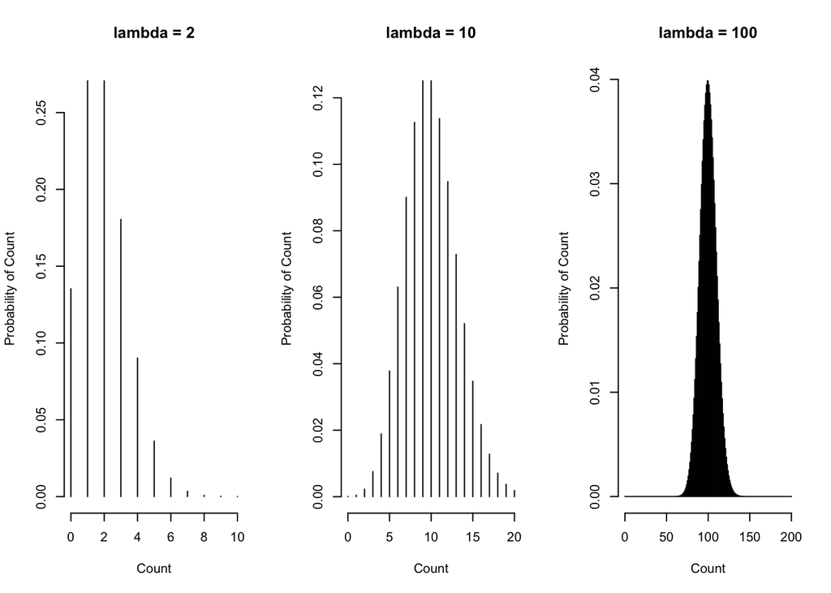

In a Poisson regression, the log of lambda is assumed to be a linear function of the predictors.

For this example, in which it is being modelled the rowth of visits to aweb sote, the log lambda will be a linear function of the date:

$log(\lambda) = b0 + b1*date$

This implies that the average number of hits per day, lambda, is exponential in the date:

$\lambda = exp(b0)*exp(b1)^{date}$

Exponential growth is also suggested by the smooth, black curve drawn though the data. Thus exp(b1) would represent the percentage by which visits grow per day.

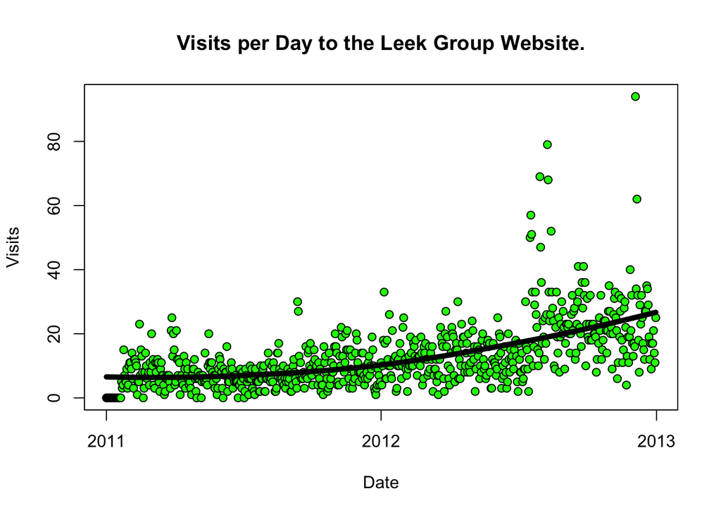

```r
class(hits[,'date'])
```

```
[1] "Date"
```

```r
as.integer(head(hits[,'date']))
```

```
[1] 14975 14976 14977 14978 14979 14980
```

```r
mdl <- glm(visits ~ date,poisson, hits)
```

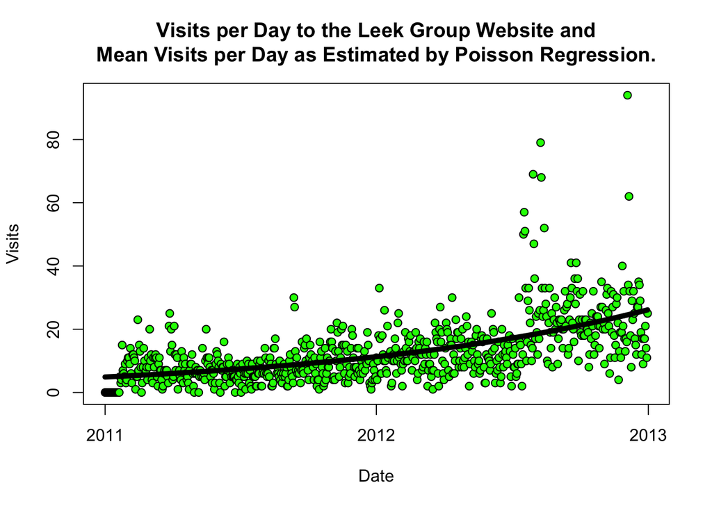

```r
summary(mdl)
```

```
Call:
glm(formula = visits ~ date, family = poisson, data = hits)

Deviance Residuals:
    Min       1Q   Median       3Q      Max
-5.0466  -1.5908  -0.3198   0.9128  10.6545

Coefficients:
              Estimate Std. Error z value Pr(>|z|)
(Intercept) -3.275e+01  8.130e-01  -40.28   <2e-16 ***
date         2.293e-03  5.266e-05   43.55   <2e-16 ***
---
Signif. codes:  0 '***' 0.001 '**' 0.01 '*' 0.05 '.' 0.1 ' ' 1

(Dispersion parameter for poisson family taken to be 1)

    Null deviance: 5150.0  on 730  degrees of freedom
Residual deviance: 3121.6  on 729  degrees of freedom
AIC: 6069.6

Number of Fisher Scoring iterations: 5
```

Both coefficients are significant. The Residual deviance is also very significantly less than the Null, indicating a strong effect.

```r
# 95% CI
exp(confint(mdl, 'date'))
```

```
   2.5 %   97.5 %
1.002192 1.002399
```

Visits are estimated to increase by a factor of between 1.002192 and 1.002399 per day.

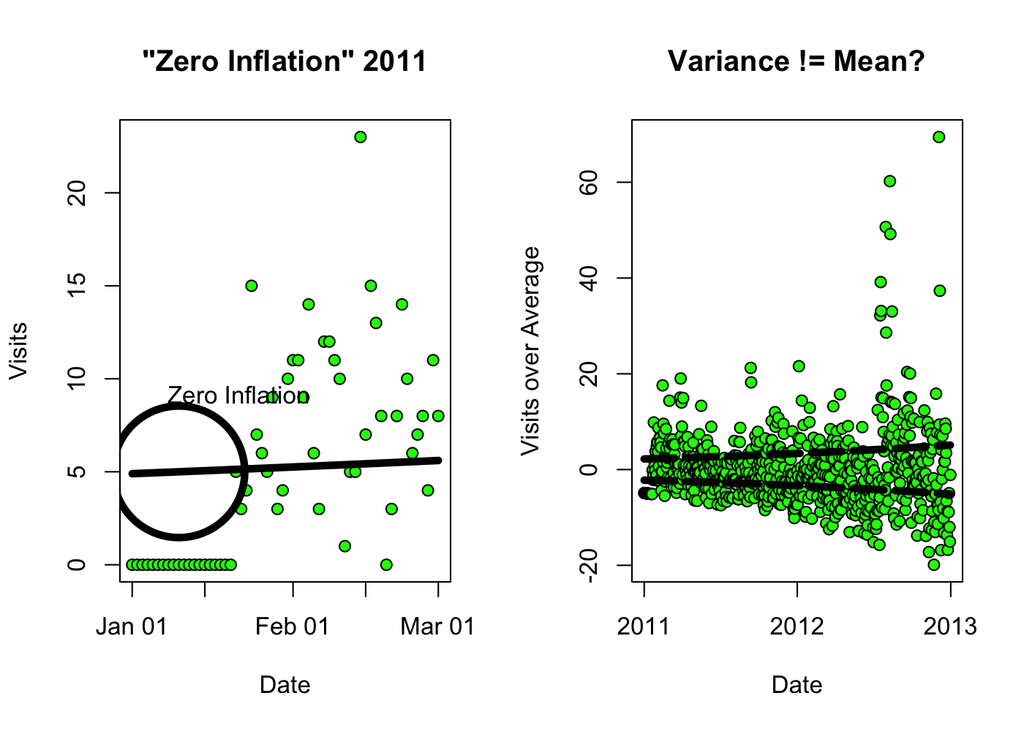

Zero inflation: The model systematically overestimates the number of visits during the 1st two weeks of JAnuary 2011, before the site had any visits.

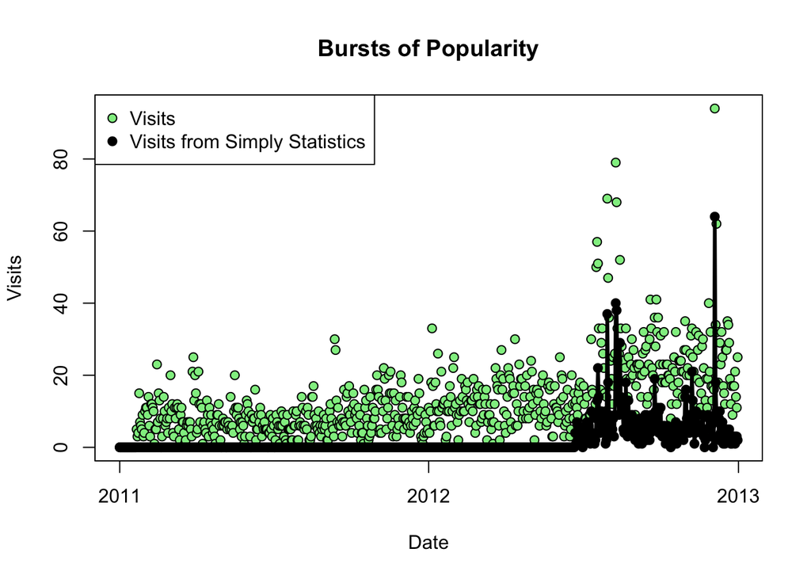

```r
plot(visits ~ date, hits, pch=21, bg='lightgreen', main="Bursts of Popularity", xlab="Date", ylab="Visits")
points(simplystats ~ date, hits, pch=21, bg='black')
lines(simplystats ~ date, hits, lwd=3)
legend('topleft', c("Visits", "Visits from Simply Statistics"), pch=21, pt.bg=c("lightgreen", "black"), bg="white")
```

Max number of visits occurred in late 2012. Visits from the Simply Statistics blog were also at their maximum that day.

```r
# Exact date
which.max(hits[,'visits'])
```

```
[1] 704
```

```r
hits[704,]
```

```
          date visits simplystats
704 2012-12-04     94          64
```

```r
# Can the difference, 94-64=30 visits, be attributed to normal traffic as
# estimated by the model?

lambda <- mdl$fitted.values[704]
qpois(.95, lambda)
```

```
[1] 33
```

So, 95% of the time there would be 33 or fewer visits, hence 30 visits would not be rare according to the model.